# GLM Modelling with mverse

This vignette aims to introduce the workflow of a multiverse analysis with GLM modelling using `mverse`.

The typical workflow of a multiverse analysis with `mverse` is

1. Initialize a `multiverse` object with the dataset.
2. Define all the different data analyses (i.e., analytical decisions) as *branches*.
3. Add defined *branches* into the `multiverse` object.
4. Run models, hypothesis tests, and plots.

# Exploring The Severity Of Feminine-named Versus Masculine-named Hurricanes

```r
library(mverse)
library(dplyr)
library(ggplot2)
```

`mverse` ships with the `hurricane` dataset used in Jung et al. (2014).

```r
glimpse(hurricane)
```

```
## Rows: 94
## Columns: 14
## $ Year                     <dbl> 1950, 1950, 1952, 1953, 1953, 1954, 1954, 195…
## $ Name                     <chr> "Easy", "King", "Able", "Barbara", "Florence"…
## $ MasFem                   <dbl> 6.777778, 1.388889, 3.833333, 9.833333, 8.333…
## $ MinPressure_before       <dbl> 958, 955, 985, 987, 985, 960, 954, 938, 962, …
## $ Minpressure_Updated_2014 <dbl> 960, 955, 985, 987, 985, 960, 954, 938, 962, …
## $ Gender_MF                <dbl> 1, 0, 0, 1, 1, 1, 1, 1, 1, 1, 0, 1, 1, 1, 1, …
## $ Category                 <dbl> 3, 3, 1, 1, 1, 3, 3, 4, 3, 1, 3, 2, 3, 1, 3, …
## $ alldeaths                <dbl> 2, 4, 3, 1, 0, 60, 20, 20, 0, 200, 7, 15, 1, …
## $ NDAM                     <dbl> 1590, 5350, 150, 58, 15, 19321, 3230, 24260, …
## $ Elapsed.Yrs              <dbl> 63, 63, 61, 60, 60, 59, 59, 59, 58, 58, 58, 5…
## $ Source                   <chr> "MWR", "MWR", "MWR", "MWR", "MWR", "MWR", "MW…
## $ HighestWindSpeed         <dbl> 120, 130, 85, 85, 85, 120, 120, 145, 120, 85,…
## $ MasFem_MTUrk             <dbl> 5.40625, 1.59375, 2.96875, 8.62500, 7.87500, …
## $ NDAM15                   <dbl> 1870, 6030, 170, 65, 18, 21375, 3520, 28500, …
```

To start a multiverse analysis, first use `create_multiverse` to create an `mverse` object with `hurricane`. At this point the multiverse is empty.

```r
hurricane_mv <- create_multiverse(hurricane)
```

# Define Branches in the Hurricane Multiverse

Each branch defines a different statistical analysis by using a subset of data, transforming columns, or a statistical model. Each combination of these branches defines a “universe”, or analysis path. Branches are defined using `X_branch(...)`, where `...` are expressions that define a data wrangling or modelling option/analytic decision that you wish to explore, such as excluding certain hurricane names from an analysis, deriving new variables for analysis (mutating), or using different models. Once branches are defined we can look at the impact of the combination of these decisions.

## Branches for Data Manipulation

`filter_branch` takes logical predicates, and finds the observations where the condition is `TRUE`.

The distribution of `alldeaths` is shown below.

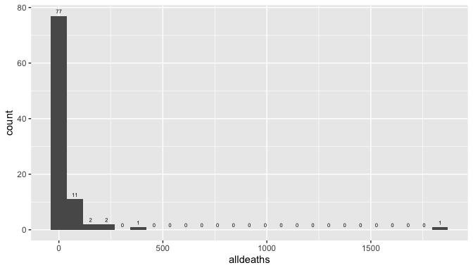

```r
hurricane |>
  ggplot(aes(alldeaths)) +
  geom_histogram(bins = 25) +
  stat_bin(
    aes(label = after_stat(count)), bins = 25,
    geom = "text", vjust = -.7, size = 2
  )
```

It looks like there are a few outliers. Let’s find out the names of these hurricanes.

```r
hurricane |>
  filter(alldeaths > median(alldeaths)) |>
  arrange(desc(alldeaths)) |>
  select(Name, alldeaths) |>
  head()
```

```
## # A tibble: 6 × 2
##   Name    alldeaths
##   <chr>       <dbl>
## 1 Katrina      1833
## 2 Audrey        416
## 3 Camille       256
## 4 Diane         200
## 5 Sandy         159
## 6 Agnes         117
```

`filter_branch()` can be used to exclude outliers. Excluding hurricane `Katrina` or `Audrey` removes the hurricanes with the most deaths.

```r
death_outliers <- filter_branch(
  none = TRUE,
  Katrina = Name != "Katrina",
  KatrinaAudrey = !(Name %in% c("Katrina", "Audrey"))
)
```

Now, let’s add this branch to `hurricane_mv`.

```r
hurricane_mv <- hurricane_mv |> add_filter_branch(death_outliers)

summary(hurricane_mv)
```

```
## # A tibble: 3 × 3
##   universe death_outliers_branch death_outliers_branch_code
##   <fct>    <fct>                 <fct>
## 1 1        none                  "TRUE"
## 2 2        Katrina               "Name != \"Katrina\""
## 3 3        KatrinaAudrey         "!(Name %in% c(\"Katrina\", \"Audrey\"))"
```

`mutate_branch()` takes expressions that can modify data columns, and can be used to provide different definitions or transformations of a column.

Consider two different definitions of femininity: `Gender_MF` is a binary classification of gender, and `MasFem` is a continuous rating of Femininity.

```r
femininity <- mutate_branch(binary = Gender_MF,
                            continuous = MasFem)
```

Consider normalized damage (`NDAM`) and the log of `NDAM`.

```r
damage <- mutate_branch(original = NDAM,
                        log = log(NDAM))
```

Now, let’s add these branches to `hurricane_mv`.

```r
hurricane_mv <- hurricane_mv |> add_mutate_branch(femininity, damage)

summary(hurricane_mv)
```

```
## # A tibble: 12 × 7
##    universe death_outliers_branch femininity_branch damage_branch
##    <fct>    <fct>                 <fct>             <fct>
##  1 1        none                  binary            original
##  2 2        none                  binary            log
##  3 3        none                  continuous        original
##  4 4        none                  continuous        log
##  5 5        Katrina               binary            original
##  6 6        Katrina               binary            log
##  7 7        Katrina               continuous        original
##  8 8        Katrina               continuous        log
##  9 9        KatrinaAudrey         binary            original
## 10 10       KatrinaAudrey         binary            log
## 11 11       KatrinaAudrey         continuous        original
## 12 12       KatrinaAudrey         continuous        log
## # ℹ 3 more variables: death_outliers_branch_code <fct>,
## #   femininity_branch_code <fct>, damage_branch_code <fct>
```

Each row of the multiverse `hurricane_mv` corresponds to each combination of `death_outliers` (3), `femininity` (2), and `damage` (2) for a total of $3 \times 2 \times 2 = 12$ combinations.

## GLM Branches for Modelling

`mverse` can define different `glm()` models as branches. The formula for a `glm` model (e.g., `y ~ x`) can be defined using `formula_branch`, and `family_branch` defines the member of the exponential family used via a `family` object.

We can create formulas using the branches above or simply use the columns in dataframe. If we use the branches `depvars`, `damage`, and `depvars` in a formula such as

`depvars ~ damage + femininity`

We can add it to `hurricane_mv` with `add_formula_branch()`.

```r
models <- formula_branch(alldeaths ~ damage + femininity)

hurricane_mv <- hurricane_mv |> add_formula_branch(models)

summary(hurricane_mv)
```

```
## # A tibble: 12 × 9
##    universe death_outliers_branch femininity_branch damage_branch models_branch
##    <fct>    <fct>                 <fct>             <fct>         <fct>
##  1 1        none                  binary            original      models_1
##  2 2        none                  binary            log           models_1
##  3 3        none                  continuous        original      models_1
##  4 4        none                  continuous        log           models_1
##  5 5        Katrina               binary            original      models_1
##  6 6        Katrina               binary            log           models_1
##  7 7        Katrina               continuous        original      models_1
##  8 8        Katrina               continuous        log           models_1
##  9 9        KatrinaAudrey         binary            original      models_1
## 10 10       KatrinaAudrey         binary            log           models_1
## 11 11       KatrinaAudrey         continuous        original      models_1
## 12 12       KatrinaAudrey         continuous        log           models_1
## # ℹ 4 more variables: death_outliers_branch_code <fct>,
## #   femininity_branch_code <fct>, damage_branch_code <fct>,
## #   models_branch_code <fct>
```

Finally, let’s create a `family_branch()` that defines two different members of the Exponential family as branches.

```r
distributions <- family_branch(poisson, gaussian)
```

Adding this branch to `hurricane_mv` with `add_family_branch()`.

```r
hurricane_mv <- hurricane_mv |> add_family_branch(distributions)

summary(hurricane_mv)
```

```
## # A tibble: 24 × 11
##    universe death_outliers_branch femininity_branch damage_branch models_branch
##    <fct>    <fct>                 <fct>             <fct>         <fct>
##  1 1        none                  binary            original      models_1
##  2 2        none                  binary            original      models_1
##  3 3        none                  binary            log           models_1
##  4 4        none                  binary            log           models_1
##  5 5        none                  continuous        original      models_1
##  6 6        none                  continuous        original      models_1
##  7 7        none                  continuous        log           models_1
##  8 8        none                  continuous        log           models_1
##  9 9        Katrina               binary            original      models_1
## 10 10       Katrina               binary            original      models_1
## # ℹ 14 more rows
## # ℹ 6 more variables: distributions_branch <fct>,
## #   death_outliers_branch_code <fct>, femininity_branch_code <fct>,
## #   damage_branch_code <fct>, models_branch_code <fct>,
## #   distributions_branch_code <fct>
```

Now, we have $12 \times 2 = 24$ different combinations.

`multiverse_tree` can be used to view `hurricane_mv`. The tree below shows that `alldeaths` is modelled using both Gaussian and Poisson distributions.

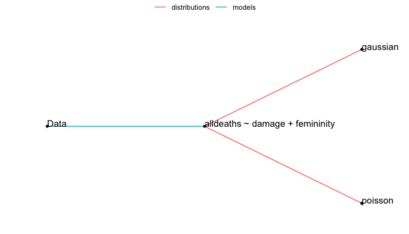

```r
multiverse_tree(hurricane_mv, label = "code", label_size = 4,
                branches = c("models", "distributions"))
```

```r
glm_mverse(hurricane_mv)

glm_summary <- summary(hurricane_mv)

glm_summary
```

```
## # A tibble: 72 × 18
##    universe death_outliers_branch femininity_branch damage_branch models_branch
##    <fct>    <fct>                 <fct>             <fct>         <fct>
##  1 1        none                  binary            original      models_1
##  2 1        none                  binary            original      models_1
##  3 1        none                  binary            original      models_1
##  4 2        none                  binary            original      models_1
##  5 2        none                  binary            original      models_1
##  6 2        none                  binary            original      models_1
##  7 3        none                  binary            log           models_1
##  8 3        none                  binary            log           models_1
##  9 3        none                  binary            log           models_1
## 10 4        none                  binary            log           models_1
## # ℹ 62 more rows
## # ℹ 13 more variables: distributions_branch <fct>, term <chr>, estimate <dbl>,
## #   std.error <dbl>, statistic <dbl>, p.value <dbl>, conf.low <dbl>,
## #   conf.high <dbl>, death_outliers_branch_code <fct>,
## #   femininity_branch_code <fct>, damage_branch_code <fct>,
## #   models_branch_code <fct>, distributions_branch_code <fct>
```

Each model has three rows, each corresponding to a summary of a model coefficient.

The specification curve for the coefficient of `femininity` is shown below.

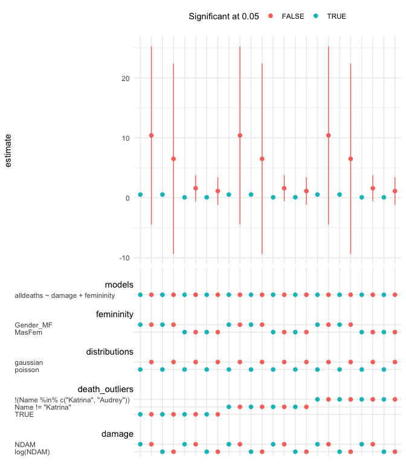

```r
spec_summary(hurricane_mv, var = "femininity") |>
  spec_curve(label = "code", spec_matrix_spacing = 4) +
  labs(colour = "Significant at 0.05") +
  theme(legend.position = "top")
```

## Condition Branches

The assumption that `alldeaths` follows a Normal distribution is tenuous, but transforming the `alldeaths` using $t(x)=\log(x+1)$ could result in a dependent variable that is closer to a Normal distribution.

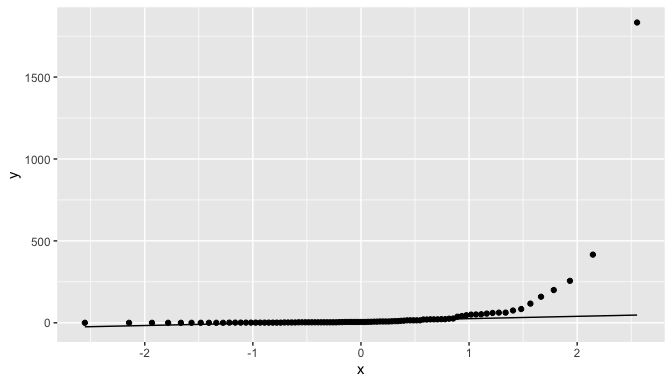

```r
hurricane |>
  ggplot(aes(sample = alldeaths)) +
  stat_qq() +
  stat_qq_line()
```

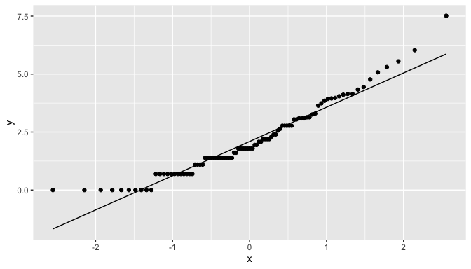

```r
hurricane |>
  mutate(logd = log(alldeaths + 1)) |>
  ggplot(aes(sample = logd)) +
  stat_qq() +
  stat_qq_line()
```

Let’s set up a similar multiverse analysis to the one above.

```r
hurricane_mv <- create_multiverse(hurricane)

dep_var <- mutate_branch(alldeaths, log(alldeaths + 1))

femininity <- mutate_branch(binary_gender = Gender_MF,
                            cts_gender = MasFem)

damage <- mutate_branch(damage_orig = NDAM,
                        damage_log = log(NDAM))

models <- formula_branch(dep_var ~ damage + femininity)

distributions <- family_branch(poisson, gaussian)

hurricane_mv <- hurricane_mv |>
  add_mutate_branch(dep_var, femininity, damage) |>
  add_formula_branch(models) |>
  add_family_branch(distributions)
```

Using `multiverse_tree()` to display the multiverse tree of `dep_var` and `distributions` shows that `log(alldeaths + 1)` and `alldeaths` will be modelled as both Gaussian and Poisson.

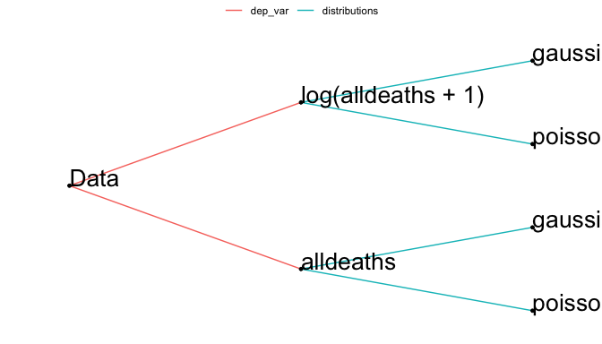

```r
multiverse_tree(hurricane_mv, label = "code", c("dep_var", "distributions"))
```

In order to specify that `hurricane_mv` should only contain analyses where `log(alldeaths + 1)` is modelled using a Gaussian and `alldeaths` modelled using Poisson we can use `branch_condition()` and `add_branch_condition()` to add it to `hurricane_mv`.

```r
match_poisson <- branch_condition(alldeaths, poisson)

match_log_lin <- branch_condition(log(alldeaths + 1), gaussian)

hurricane_mv <- add_branch_condition(hurricane_mv, match_poisson, match_log_lin)
```

The multiverse tree shows that `log(alldeaths + 1)` will *only* be modelled as Gaussian and `alldeaths` will *only* be modelled as Poisson.

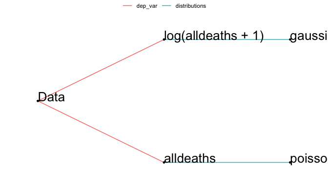

```r
multiverse_tree(hurricane_mv, label = "code", c("dep_var", "distributions"))
```

```r
glm_mverse(hurricane_mv)

summary(hurricane_mv)
```

```
## # A tibble: 24 × 18
##    universe femininity_branch damage_branch models_branch distributions_branch
##    <fct>    <fct>             <fct>         <fct>         <fct>
##  1 1        binary_gender     damage_orig   models_1      distributions_1
##  2 1        binary_gender     damage_orig   models_1      distributions_1
##  3 1        binary_gender     damage_orig   models_1      distributions_1
##  4 2        binary_gender     damage_orig   models_1      distributions_2
##  5 2        binary_gender     damage_orig   models_1      distributions_2
##  6 2        binary_gender     damage_orig   models_1      distributions_2
##  7 3        binary_gender     damage_log    models_1      distributions_1
##  8 3        binary_gender     damage_log    models_1      distributions_1
##  9 3        binary_gender     damage_log    models_1      distributions_1
## 10 4        binary_gender     damage_log    models_1      distributions_2
## # ℹ 14 more rows
## # ℹ 13 more variables: dep_var_branch <fct>, term <chr>, estimate <dbl>,
## #   std.error <dbl>, statistic <dbl>, p.value <dbl>, conf.low <dbl>,
## #   conf.high <dbl>, femininity_branch_code <fct>, damage_branch_code <fct>,
## #   models_branch_code <fct>, distributions_branch_code <fct>,
## #   dep_var_branch_code <fct>
```

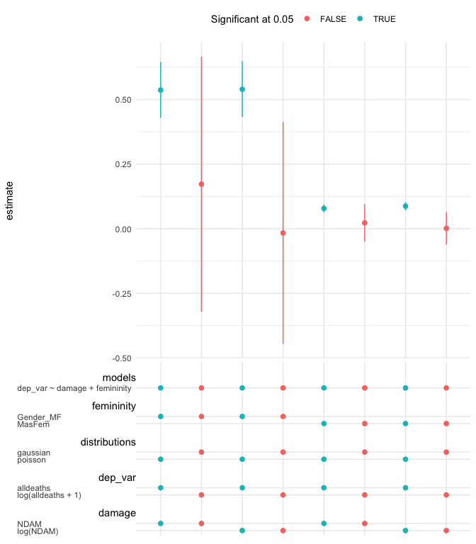

```r
spec_summary(hurricane_mv, var = "femininity") |>
  spec_curve(label = "code", spec_matrix_spacing = 4) +
  labs(colour = "Significant at 0.05") +
  theme(legend.position = "top")
```

## Negative Binomial Regression

Jung et al. (2014) used negative binomial regression to analyse the severity of female versus male hurricane names on number of deaths. In this section we will `glm.nb_mverse()` to do a similar analysis.

First, let’s setup the multiverse of analyses.

```r
hurricane_nb_mv <- create_multiverse(hurricane)

femininity <- mutate_branch(binary_gender = Gender_MF,
                            cts_gender = MasFem)

damage <- mutate_branch(damage_orig = NDAM,
                        damage_log = log(NDAM))

models <- formula_branch(alldeaths ~ damage + femininity)

hurricane_nb_mv <- hurricane_nb_mv |>
  add_mutate_branch(femininity, damage) |>
  add_formula_branch(models)
```

A summary of `hurricane_nb_mv` shows the four models in the multiverse.

```r
summary(hurricane_nb_mv)
```

```
## # A tibble: 4 × 7
##   universe femininity_branch damage_branch models_branch femininity_branch_code
##   <fct>    <fct>             <fct>         <fct>         <fct>
## 1 1        binary_gender     damage_orig   models_1      Gender_MF
## 2 2        binary_gender     damage_log    models_1      Gender_MF
## 3 3        cts_gender        damage_orig   models_1      MasFem
## 4 4        cts_gender        damage_log    models_1      MasFem
## # ℹ 2 more variables: damage_branch_code <fct>, models_branch_code <fct>
```

Next, use `glm.nb_mverse()` to fit the negative binomial regressions.

```r
glm.nb_mverse(hurricane_nb_mv)

summary(hurricane_nb_mv)
```

```
## # A tibble: 12 × 14
##    universe femininity_branch damage_branch models_branch term          estimate
##    <fct>    <fct>             <fct>         <fct>         <chr>            <dbl>
##  1 1        binary_gender     damage_orig   models_1      (Intercept)  1.71
##  2 1        binary_gender     damage_orig   models_1      damage       0.0000981
##  3 1        binary_gender     damage_orig   models_1      femininity   0.227
##  4 2        binary_gender     damage_log    models_1      (Intercept) -1.96
##  5 2        binary_gender     damage_log    models_1      damage       0.577
##  6 2        binary_gender     damage_log    models_1      femininity   0.108
##  7 3        cts_gender        damage_orig   models_1      (Intercept)  1.66
##  8 3        cts_gender        damage_orig   models_1      damage       0.0000983
##  9 3        cts_gender        damage_orig   models_1      femininity   0.0304
## 10 4        cts_gender        damage_log    models_1      (Intercept) -2.05
## 11 4        cts_gender        damage_log    models_1      damage       0.576
## 12 4        cts_gender        damage_log    models_1      femininity   0.0240
## # ℹ 8 more variables: std.error <dbl>, statistic <dbl>, p.value <dbl>,
## #   conf.low <dbl>, conf.high <dbl>, femininity_branch_code <fct>,
## #   damage_branch_code <fct>, models_branch_code <fct>
```

Finally, we can plot the specification curve.

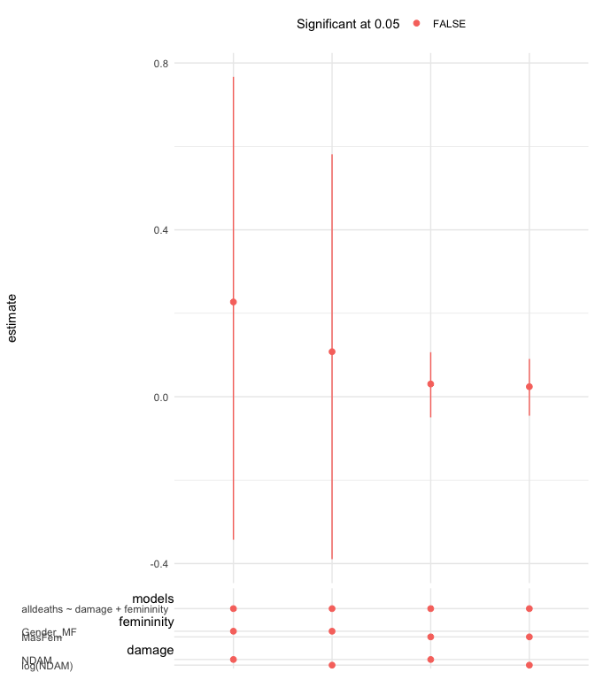

```r
spec_summary(hurricane_nb_mv, var = "femininity") |>
  spec_curve(label = "code", spec_matrix_spacing = 4) +
  labs(colour = "Significant at 0.05") +
  theme(legend.position = "top")
```

Jung, Kiju, Sharon Shavitt, Madhu Viswanathan, and Joseph M. Hilbe. 2014. “Female Hurricanes Are Deadlier Than Male Hurricanes” 111 (24): 8782–87. https://doi.org/10.1073/pnas.1402786111.